# Counting Palm Tree from Satellite image

This is an attempt to count palm tree from satellite image. Few palm tree image will be use as samples, match it to a palm tree farm satellite image, then capture & count palm trees in the farm.

### Import libraries

```python
import numpy as np
from PIL import Image
import matplotlib.pyplot as plt
from pylab import *
%matplotlib inline
```

### Load and Display sample palm tree image

```
loaded 6 sample images
```

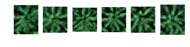

```python
sample_count = 6
image_list = []

for i in range(sample_count):
    file_num = i + 1
    image_list.append(np.asarray(Image.open('palm_tree_%s.png' % file_num)))
    plt.subplot(1,sample_count,file_num).imshow(image_list[i])
    plt.axis('off')
print('loaded %s sample images' % len(image_list))
```

### Load and Display full image of palm tree farm

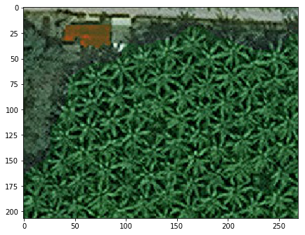

```python
imageTotal = np.asarray(Image.open('palm_tree_full.png'))
figure(figsize = (7,7))
imshow(imageTotal);
```

### Pre-process image

```
pre-processed 6 sample images
```

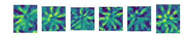

```python
sample_img = []
for i in range(sample_count):
    samp_num = i + 1
    sample_img.append(image_list[i][:,:,1])
    plt.subplot(1,sample_count,samp_num).imshow(sample_img[i])
    plt.axis('off')
print('pre-processed %s sample images' % len(sample_img))
```

```
pre-processed full image
```

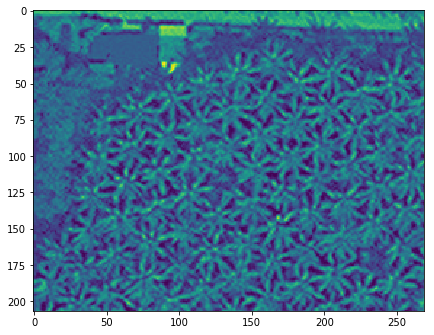

```python
full_img = imageTotal[:,:,1]
figure(figsize = (7,7))
imshow(full_img);
print('pre-processed full image')
```

### Match template with scikit-image

Sample image will be match with full image using normalized correlation.

```python
from skimage.feature import match_template

result_list = []
for i in range(sample_count):
    result_list.append(match_template(full_img, sample_img[i]))
print('Matches %s sample images to full image, to get correlations.' % len(result_list))
```

```
Matches 6 sample images to full image, to get correlations.
```

### Filter high correlation result to get data point

#### Challenges:

With low pixel image download from Google search. Correlation thresholds need to be set with trial and error test. Because of low pixel image, correlation thresholds have to be low, enabling capture more data point. However, a low correlation threshold may cause wrong data point captured. This stage will be revisit to find optimum result.

```python
filter_result = []
filter_result.append(np.where(result_list[0]>0.35))
filter_result.append(np.where(result_list[1]>0.35))
filter_result.append(np.where(result_list[2]>0.30))
filter_result.append(np.where(result_list[3]>0.30))
filter_result.append(np.where(result_list[4]>0.30))
filter_result.append(np.where(result_list[5]>0.30))
```

### Number of data point captured after matching each sample

```python
for i in range(sample_count):
    print('filter_result[%s] = %s' % (i, shape(filter_result[i])[1]))
```

```
filter_result[0] = 55
filter_result[1] = 43
filter_result[2] = 33
filter_result[3] = 117
filter_result[4] = 74
filter_result[5] = 111
```

### Compiling all matches samples

result are now with data point from all samples.

```python
result = np.concatenate(filter_result,axis=1)
result = np.swapaxes(result,0,1)
result = result[result[:, 0].argsort()]
result = np.swapaxes(result,0,1)
```

```python
print('Total data point collected =', len(result[0]))
```

```
Total data point collected = 433
```

### Clean up duplicate data point

Data point are captured from multiple samples, same data point may captured multiple time, which can cause duplicate. Clean up is needed. When multiple data point captured is too near in range, we can ignore it. Only capture the first data point.

```python
n = 0
m = 0
captured = ([],[])
for i in range(len(result[0])):
    this = result[0][i]
    if this not in range(m,n):
        captured[0].append(result[0][i])
        captured[1].append(result[1][i])
        m = this
        n = this + 4
captured =(np.asarray(captured[0]),np.asarray(captured[1]))
```

### Data point captured

```python
captured
```

```
(array([ 20,  26,  30,  34,  39,  45,  49,  53,  57,  63,  67,  71,  75,
         79,  83,  87,  91,  95, 101, 105, 109, 113, 117, 122, 126, 130,
        134, 138, 142, 146, 150, 154, 159, 164, 168, 172, 176], dtype=int64),
 array([152, 134, 127, 236, 234,  85, 149, 193, 166, 102,  98, 145,  82,
        184, 119, 226, 206, 139, 183,  53,  28,  30, 203,  72, 180,  45,
        221,  26, 130,  65, 239, 170, 151, 199, 191, 237, 108], dtype=int64))
```

### Counting Palm Tree

```python
print('Number of palm trees in the farm =', len(captured[0]))
```

```
Number of palm trees in the farm = 37
```

### Palm Trees captured in Palm Tree Farm satellite image

As visualization shows, with low pixel image, is hard to capture all palm trees. There's also a few duplicate count even after data cleaning. Therefore number of palm tree count is inaccurate. However, we can expect to have higher accuracy with high pixel image.

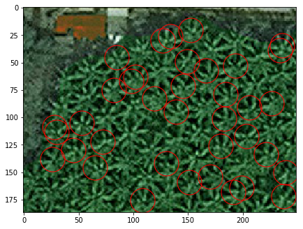

```python
figure(figsize = (7,7))
for punto in range(shape(captured)[1]):
    plot(captured[1][punto],captured[0][punto], 'o',
        markeredgecolor='r', markerfacecolor='none', markersize=35)

imshow(imageTotal[10:-10,10:-10,:]);
```